# Flexible Damage Functions

Author

James Rising, Sebastian Cadavid Sanchez, Climate Impact Lab

Published

April 30, 2026

## 0.1 Energy: Non Electricity Country Unconstrained

Flexible damage function parameters at the Country level.

**Outcome units:** `kWh_per_capita` — kWh per capita for non electricity, rebased to 2005 baseline; DIAGNOSTIC variant with NO beta constraint applied (allows beta < 0 = concave temperature response). Compare with the constrained non_electricity_country version to see where the convexity constraint is binding and how it shifts the regional fit.

$$D_{it} = (\alpha_i T_t + \beta_i T_t^2) \cdot Y_{it}^{\gamma}$$

where $\gamma$ is the income elasticity (fitted globally), $\alpha_i$ is the linear coefficient, and $\beta_i$ is the quadratic coefficient.

# 1 Global Estimation

## 1.1 Income Elasticity Estimation

The income elasticity $\gamma$ is estimated using a fixed-effects regression:

$$y_{it} = \gamma \cdot \log(Y_{it}) + \mu_{g(i,T)} + \nu_t + \varepsilon_{it}$$

where $\mu_{g(i,T)}$ are region-by-temperature-bin fixed effects and $\nu_t$ are year fixed effects.

Table 1: Income Elasticity (Gamma) Estimation Results

| Statistic | Value |
| --- | --- |
| Income elasticity ($\gamma$) | -0.2307 |
| Standard error | 2.02e-02 |
| 95% CI | [-0.2703, -0.1910] |
| R-squared | 0.9098 |
| Observations | 3,519,180 |
| Regions | 245 |
| Gamma quantiles | 19 |

# 2 Parameter Distributions

## 2.1 8-Panel Summary

Row 1: gamma, alpha, beta, rsqr1. Row 2: rho, zeta, eta, rsqr2.

```
Using median gamma: -0.230683, 245 rows (of 4,655 total)
```

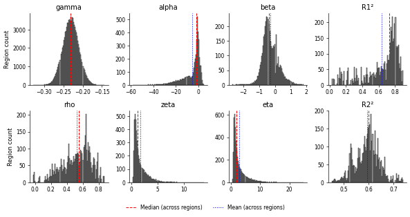

Figure 1: Distribution of Regional Parameters

## 2.2 Projection Equation and Parameter Definitions

The estimated parameters are used to project damages via Monte Carlo sampling:

$$D_{it}^k = (\hat{\alpha}_{ik} T_t + \hat{\beta}_{ik} T_t^2) Y_{it}^{\hat{\gamma}_k} + \hat{\theta}_{ik} T_t Y_{it}^{\hat{\gamma}_k} + \hat{\phi}_{it}^k$$

where $k$ indexes the Monte Carlo draw. The parameters in each row of the output CSV control distinct components of this equation:

- **gamma**: income elasticity $\hat{\gamma}_k$, one of 19 quantile values drawn from $N(\hat{\gamma}, SE(\hat{\gamma}))$
- **alpha, beta**: linear and quadratic temperature coefficients; $\hat{\alpha}_{ik}$ and $\hat{\beta}_{ik}$ are drawn from the joint normal defined by the VCV below
- **sigma11, sigma12, sigma22**: variance-covariance matrix of $(\alpha, \beta)$, used for joint uncertainty sampling
- **rho**: correlation between regional and global polynomial residuals $\rho_i$, used to maintain spatial covariance across regions in Monte Carlo draws
- **zeta**: temperature-dependent error scale $\zeta_{ik}$; the run-specific error term $\hat{\theta}_{ik}$ is drawn from $N(0, \zeta_{ik})$
- **eta**: residual noise standard deviation $\eta_{ik}$; the annual noise $\hat{\phi}_{it}^k$ is drawn from $N(0, \eta_{ik})$
- **rsqr1, rsqr2**: polynomial fit quality and error model fit, respectively

## 2.3 Summary Statistics

Table 2: Regional Parameter Summary

| Parameter | Mean | Median | Std | Min | Max | N |
| --- | --- | --- | --- | --- | --- | --- |
| alpha | -5.452 | -1.9 | 8.249 | -41.58 | 3.814 | 245 |
| beta | -0.2865 | -0.3798 | 0.4914 | -1.796 | 1.422 | 245 |
| rho | 0.5219 | 0.5455 | 0.1831 | -0.01837 | 0.8739 | 245 |
| zeta | 1.674 | 1.157 | 1.361 | 0.3681 | 9.681 | 245 |
| eta | 2.807 | 1.891 | 2.401 | 0.6644 | 17.28 | 245 |
| rsqr1 | 0.6386 | 0.7298 | 0.2163 | 0.02492 | 0.8967 | 245 |
| rsqr2 | 0.5944 | 0.5983 | 0.04888 | 0.4594 | 0.7333 | 245 |

# 3 Spaghetti Curves

Regional damage function curves showing D(T) = αT + βT² for sampled regions.

[interactive chart not shown]

Figure 2: Regional Damage Functions

# 4 Zero Crossings

The zero crossing (extremum) of the parabola occurs at $T^* = -\alpha / (2\beta)$.

Table 3: Zero Crossing Statistics

| Category | Count | Percentage |
| --- | --- | --- |
| β = 0 (no crossing) | 0 | 0.0% |
| T > 20°C (beyond graph) | 38 | 15.5% |
| T < 0°C (negative crossing) | 127 | 51.8% |
| Valid crossings (0-20°C) | 80 | 32.7% |

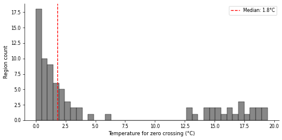

Figure 3: Distribution of Zero Crossing Temperatures

# 5 Slope Analysis

Maximum slope between 0 and 10°C: $\frac{dM}{dT} = \alpha + 2\beta T$

The maximum occurs at either T=0 or T=10 (endpoints of interval).

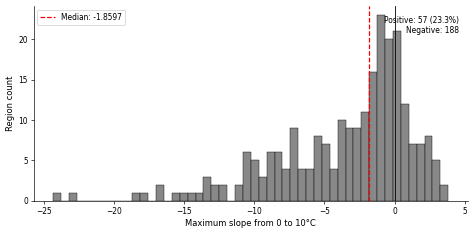

Figure 4: Distribution of Maximum Slopes (0-10°C)

# 6 Convexity Analysis

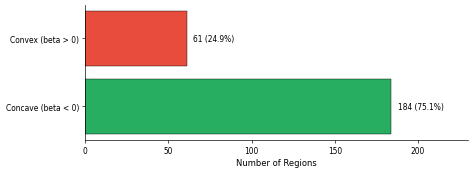

Figure 5: Beta Sign Distribution (Convexity)

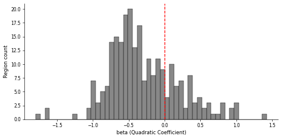

Figure 6: Beta Distribution

## 6.1 Convexity by Country

Table 4: Fraction of Convex (beta > 0) Regions by Country (top 20)

| country | n_regions | n_convex | frac_convex |
| --- | --- | --- | --- |
| ALA | 1 | 1 | 100.0% |
| AND | 1 | 1 | 100.0% |
| ARM | 1 | 1 | 100.0% |
| AUS | 1 | 1 | 100.0% |
| AUT | 1 | 1 | 100.0% |
| AZE | 1 | 1 | 100.0% |
| BEL | 1 | 1 | 100.0% |
| BGR | 1 | 1 | 100.0% |
| BIH | 1 | 1 | 100.0% |
| BLR | 1 | 1 | 100.0% |
| BTN | 1 | 1 | 100.0% |
| CAN | 1 | 1 | 100.0% |
| CHE | 1 | 1 | 100.0% |
| CHL | 1 | 1 | 100.0% |
| CHN | 1 | 1 | 100.0% |
| CZE | 1 | 1 | 100.0% |
| DEU | 1 | 1 | 100.0% |
| DNK | 1 | 1 | 100.0% |
| EST | 1 | 1 | 100.0% |
| FIN | 1 | 1 | 100.0% |

# 7 R-squared Analysis

## 7.1 Polynomial Fit Quality (rsqr1)

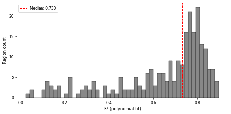

Figure 7: Regional Fit Quality (R-squared)

## 7.2 Error Model R-squared (rsqr2) Quantiles

Table 5: rsqr2 Quantiles

| 0% (Min) | 25% | 50% (Median) | 75% | 100% (Max) |
| --- | --- | --- | --- | --- |
| 0.4594 | 0.5626 | 0.5983 | 0.6240 | 0.7333 |

# 8 Modelled Variance

Modelled variance statistic: $1 - \frac{\sum_i \eta_i^2}{\sum_i D_i^2}$

Table 6: Modelled Variance Statistics

| Statistic | Value |
| --- | --- |
| Modelled variance | 0.9833 |
| Sum(η²) | 3337.7198 |
| Sum(D²) at T=3.0°C | 200255.3530 |
| N regions | 245 |

# 9 Best- and Worst-Fitting Regions

The 3 worst- and 3 best-fitting regions by R-squared, with raw simulation data overlaid on the fitted polynomial curve. **Red rows = worst fits**, **green rows = best fits**.

Table 7: Best- and worst-fitting regions

Top 3 best fit (R²) Top 3 worst fit (R²)

| Region | α | β | η | R² |
| --- | --- | --- | --- | --- |
| ARE | -7.61 | -1.26 | 2.88 | 0.897 |
| QAT | -10.5 | -1.8 | 4.1 | 0.894 |
| SAU | -4.74 | -1.01 | 2.13 | 0.889 |
| STP | 1.73 | -0.342 | 1.92 | 0.0249 |
| CPV | 1.48 | -0.374 | 1.79 | 0.0501 |
| SWZ | 1.45 | -0.383 | 1.57 | 0.0511 |

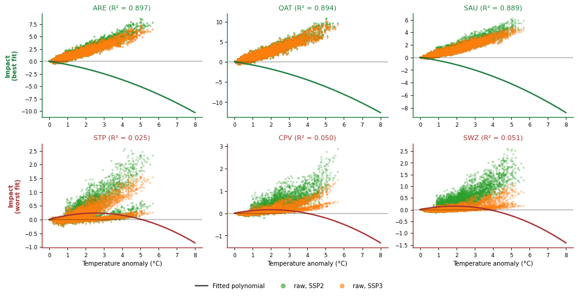

# 10 Regional Parameter Maps

Maps of key parameters at the **country** level. Red = negative (damage increases with T), Blue = positive.

## 10.1 Alpha (Linear Coefficient)

Alpha ($\alpha$) represents the linear sensitivity to temperature. Regions with negative alpha experience damage that increases with the first degree of warming.

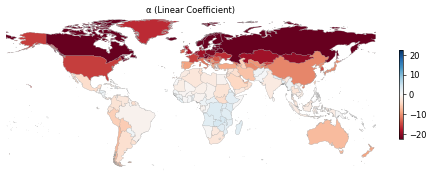

Figure 9: α (linear coefficient)

## 10.2 Beta (Quadratic Coefficient)

Beta ($\beta$) represents the curvature of the damage function.

The **no constraint applied** (β unconstrained) constraint is enforced for this sector, meaning this is an unconstrained diagnostic run. β can take either sign, letting the data choose convex or concave shape per region..

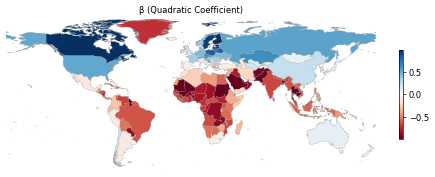

Figure 10: β (quadratic coefficient)

## 10.3 R-squared (Fit Quality)

$R^2$ measures the polynomial fit quality. Higher values indicate that the quadratic form captures more of the variance in the data.

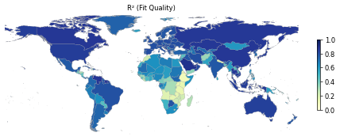

Figure 11: R² (stage 1 fit quality)

# 11 F2: Flex vs Raw Comparison

Comparison of flexible damage function predictions against raw simulation means.

For each scenario (RCP × SSP × Model), we compute at the final year:

- **Flex predicted**: $(\alpha \cdot T + \beta \cdot T^2) \cdot Y^\gamma$
- **Raw actual**: The outcome variable (y) from the source data

**Year 2099**: 65,780 rows

**rcp45**

**SSP2**

**high**

**Correlation:** 0.7048 | **RMSE:** 1.729406 | **Sign agreement:** 25.7%

[interactive chart not shown]

Top 5 best predicted Top 5 worst predicted

Year 2099 · T<sub>mean</sub> across these regions: 1.96°C

| Region | Raw | Flex | Residual |
| --- | --- | --- | --- |
| RWA | 0.378 | 0.385 | 0.00726 |
| ERI | 0.324 | 0.282 | -0.0422 |
| BDI | 0.546 | 0.355 | -0.191 |
| MDG | 0.514 | 0.314 | -0.2 |
| KEN | 0.528 | 0.299 | -0.23 |
| QAT | 2.87 | -1.62 | -4.49 |
| KWT | 2.57 | -1.37 | -3.93 |
| ARE | 2.43 | -1.27 | -3.71 |
| BHR | 2.16 | -1.36 | -3.52 |
| FIN | -1.11 | -4.51 | -3.4 |

**low**

**Correlation:** 0.5972 | **RMSE:** 1.675283 | **Sign agreement:** 25.3%

[interactive chart not shown]

Top 5 best predicted Top 5 worst predicted

Year 2099 · T<sub>mean</sub> across these regions: 1.96°C

| Region | Raw | Flex | Residual |
| --- | --- | --- | --- |
| KEN | 0.318 | 0.349 | 0.0305 |
| STP | 0.177 | 0.217 | 0.0408 |
| ERI | 0.361 | 0.283 | -0.0782 |
| COM | 0.326 | 0.225 | -0.101 |
| NPL | 0.317 | 0.206 | -0.111 |
| QAT | 2.87 | -1.62 | -4.49 |
| SJM | -2.28 | -6.44 | -4.16 |
| ARE | 2.43 | -1.27 | -3.71 |
| KWT | 2.14 | -1.51 | -3.66 |
| EST | -0.601 | -4.19 | -3.59 |

**SSP3**

**high**

**Correlation:** 0.5565 | **RMSE:** 1.678891 | **Sign agreement:** 25.7%

[interactive chart not shown]

Top 5 best predicted Top 5 worst predicted

Year 2099 · T<sub>mean</sub> across these regions: 1.96°C

| Region | Raw | Flex | Residual |
| --- | --- | --- | --- |
| MOZ | 0.252 | 0.254 | 0.00174 |
| COD | 0.293 | 0.323 | 0.0294 |
| ZMB | 0.393 | 0.426 | 0.0328 |
| AGO | 0.223 | 0.273 | 0.0492 |
| COM | 0.202 | 0.255 | 0.0528 |
| SJM | -1.68 | -6.91 | -5.24 |
| QAT | 2.66 | -1.71 | -4.36 |
| FIN | -0.964 | -4.82 | -3.86 |
| KWT | 2.14 | -1.53 | -3.67 |
| LUX | 0.00734 | -3.49 | -3.5 |

**low**

**Correlation:** 0.4403 | **RMSE:** 1.706711 | **Sign agreement:** 26.5%

[interactive chart not shown]

Top 5 best predicted Top 5 worst predicted

Year 2099 · T<sub>mean</sub> across these regions: 1.96°C

| Region | Raw | Flex | Residual |
| --- | --- | --- | --- |
| LBR | 0.27 | 0.246 | -0.0233 |
| AGO | 0.223 | 0.273 | 0.0492 |
| CPV | 0.115 | 0.178 | 0.0631 |
| COD | 0.288 | 0.36 | 0.0718 |
| MOZ | 0.236 | 0.351 | 0.115 |
| SJM | -0.907 | -7.54 | -6.63 |
| MNG | 0.11 | -4.61 | -4.72 |
| QAT | 2.66 | -1.71 | -4.36 |
| FIN | -0.948 | -4.85 | -3.9 |
| EST | -0.532 | -4.38 | -3.84 |

**rcp85**

**SSP2**

**high**

**Correlation:** 0.5895 | **RMSE:** 4.329318 | **Sign agreement:** 15.1%

[interactive chart not shown]

Top 5 best predicted Top 5 worst predicted

Year 2099 · T<sub>mean</sub> across these regions: 4.20°C

| Region | Raw | Flex | Residual |
| --- | --- | --- | --- |
| ERI | 0.85 | 0.198 | -0.652 |
| RWA | 1.34 | 0.569 | -0.771 |
| PCN | 0.629 | -0.266 | -0.896 |
| MDG | 1.35 | 0.403 | -0.95 |
| BDI | 1.72 | 0.587 | -1.14 |
| QAT | 7.33 | -4.48 | -11.8 |
| KWT | 6.83 | -3.93 | -10.8 |
| ARE | 6.11 | -3.51 | -9.62 |
| BHR | 5.53 | -4.02 | -9.55 |
| SAU | 5.12 | -2.71 | -7.83 |

**low**

**Correlation:** 0.4513 | **RMSE:** 4.105743 | **Sign agreement:** 15.1%

[interactive chart not shown]

Top 5 best predicted Top 5 worst predicted

Year 2099 · T<sub>mean</sub> across these regions: 4.20°C

| Region | Raw | Flex | Residual |
| --- | --- | --- | --- |
| ETH | 0.139 | 0.373 | 0.234 |
| ZWE | 0.325 | 0.659 | 0.334 |
| MDG | 0.218 | 0.558 | 0.339 |
| TZA | 0.488 | 0.118 | -0.37 |
| STP | 0.503 | 0.13 | -0.373 |
| QAT | 7.33 | -4.48 | -11.8 |
| KWT | 5.69 | -4.35 | -10 |
| BHR | 5.76 | -3.94 | -9.7 |
| ARE | 6.11 | -3.51 | -9.62 |
| SJM | -3.73 | -12.7 | -8.96 |

**SSP3**

**high**

**Correlation:** 0.4107 | **RMSE:** 4.061552 | **Sign agreement:** 14.3%

[interactive chart not shown]

Top 5 best predicted Top 5 worst predicted

Year 2099 · T<sub>mean</sub> across these regions: 4.20°C

| Region | Raw | Flex | Residual |
| --- | --- | --- | --- |
| MWI | 0.562 | 0.46 | -0.103 |
| KEN | 0.435 | 0.293 | -0.142 |
| ERI | 0.465 | 0.293 | -0.171 |
| ETH | 0.192 | 0.37 | 0.178 |
| ZWE | 0.413 | 0.595 | 0.181 |
| QAT | 6.92 | -4.72 | -11.6 |
| SJM | -2.74 | -13.6 | -10.9 |
| KWT | 5.8 | -4.4 | -10.2 |
| ARE | 5.07 | -3.99 | -9.06 |
| BHR | 4.39 | -4.56 | -8.95 |

**low**

**Correlation:** 0.2959 | **RMSE:** 4.098118 | **Sign agreement:** 14.7%

[interactive chart not shown]

Top 5 best predicted Top 5 worst predicted

Year 2099 · T<sub>mean</sub> across these regions: 4.20°C

| Region | Raw | Flex | Residual |
| --- | --- | --- | --- |
| STP | 0.225 | 0.175 | -0.0499 |
| MWI | 0.526 | 0.609 | 0.0838 |
| KEN | 0.277 | 0.371 | 0.094 |
| ERI | 0.476 | 0.277 | -0.199 |
| SWZ | 0.247 | -0.0791 | -0.326 |
| SJM | -1.48 | -14.9 | -13.4 |
| QAT | 6.92 | -4.72 | -11.6 |
| MNG | 0.25 | -9.81 | -10.1 |
| KWT | 5.37 | -4.52 | -9.89 |
| BHR | 5.15 | -4.22 | -9.37 |

## 11.1 Scenario Summary

| RCP | SSP | Model | N | Corr | RMSE | Sign% |
| --- | --- | --- | --- | --- | --- | --- |
| rcp45 | SSP2 | high | 245 | 0.7048 | 1.72941 | 25.7% |
| rcp45 | SSP2 | low | 245 | 0.5972 | 1.67528 | 25.3% |
| rcp45 | SSP3 | high | 245 | 0.5565 | 1.67889 | 25.7% |
| rcp45 | SSP3 | low | 245 | 0.4403 | 1.70671 | 26.5% |
| rcp85 | SSP2 | high | 245 | 0.5895 | 4.32932 | 15.1% |
| rcp85 | SSP2 | low | 245 | 0.4513 | 4.10574 | 15.1% |
| rcp85 | SSP3 | high | 245 | 0.4107 | 4.06155 | 14.3% |
| rcp85 | SSP3 | low | 245 | 0.2959 | 4.09812 | 14.7% |

# 12 Data Reference

## 12.1 File Locations

| Item | Path |
| --- | --- |
| Regional CSV | `/project/cil/gcp/flex_damage_funcs/parameters/energy__non_electricity_country_unconstrained__regional_parameters.csv` |
| Global JSON | `/project/cil/gcp/flex_damage_funcs/parameters/energy__non_electricity_country_unconstrained__global_results.json` |
| Metadata JSON | `/project/cil/gcp/flex_damage_funcs/parameters/energy__non_electricity_country_unconstrained__metadata.json` |

## 12.2 Column Definitions

| Column | Description |
| --- | --- |
| `region` | Region identifier (hierarchical code, first 3 chars = country ISO3) |
| `gamma` | Income elasticity quantile value |
| `alpha` | Linear temperature coefficient |
| `beta` | Quadratic temperature coefficient |
| `sigma11` | Var(alpha) |
| `sigma12` | Cov(alpha, beta) |
| `sigma22` | Var(beta) |
| `rho` | Correlation with global residual process |
| `zeta` | Temperature-dependent heteroskedasticity |
| `eta` | Residual standard deviation |
| `rsqr1` | R-squared of polynomial fit |
| `rsqr2` | R-squared of error model |

*Report generated with FlexDamage v1.0.0*